# 项目：探索TMDb电影数据

## 目录

- 简介
- 数据整理
- 探索性数据分析
- 结论

## 简介

> 本次分析的数据为TMDB的电影评分数据。研究问题一：流行程度'popularity'和得分'vote_average'之间的关系，投入'budget_adj'和收入'revenue_adj'之间的关系。研究问题二：电影是否拥有自己的主页，会不会影响其popularity和vote_average？

```python
import pandas as pd
import matplotlib.pyplot as plt
import seaborn as sns
import numpy as np
% matplotlib inline
```

## 数据整理

### 常规属性

```python
# 加载数据并打印几行。进行这几项操作，来检查数据
#   类型，以及是否有缺失数据或错误数据的情况。
df = pd.read_csv('tmdb-movies.csv')
print(df.columns)
print(df.head())
print(df.dtypes)
```

```
Index(['id', 'imdb_id', 'popularity', 'budget', 'revenue', 'original_title',
       'cast', 'homepage', 'director', 'tagline', 'keywords', 'overview',
       'runtime', 'genres', 'production_companies', 'release_date',
       'vote_count', 'vote_average', 'release_year', 'budget_adj',
       'revenue_adj'],
      dtype='object')
       id    imdb_id  popularity     budget     revenue  \
0  135397  tt0369610   32.985763  150000000  1513528810
1   76341  tt1392190   28.419936  150000000   378436354
2  262500  tt2908446   13.112507  110000000   295238201
3  140607  tt2488496   11.173104  200000000  2068178225
4  168259  tt2820852    9.335014  190000000  1506249360

                 original_title  \
0                Jurassic World
1            Mad Max: Fury Road
2                     Insurgent
3  Star Wars: The Force Awakens
4                     Furious 7

                                                cast  \
0  Chris Pratt|Bryce Dallas Howard|Irrfan Khan|Vi...
1  Tom Hardy|Charlize Theron|Hugh Keays-Byrne|Nic...
2  Shailene Woodley|Theo James|Kate Winslet|Ansel...
3  Harrison Ford|Mark Hamill|Carrie Fisher|Adam D...
4  Vin Diesel|Paul Walker|Jason Statham|Michelle ...

                                            homepage          director  \
0                      http://www.jurassicworld.com/   Colin Trevorrow
1                        http://www.madmaxmovie.com/     George Miller
2     http://www.thedivergentseries.movie/#insurgent  Robert Schwentke
3  http://www.starwars.com/films/star-wars-episod...       J.J. Abrams
4                           http://www.furious7.com/         James Wan

                         tagline      ...       \
0              The park is open.      ...
1             What a Lovely Day.      ...
2     One Choice Can Destroy You      ...
3  Every generation has a story.      ...
4            Vengeance Hits Home      ...
```

[output cut: 37 more lines]

```
homepage                 object
director                 object
tagline                  object
keywords                 object
overview                 object
runtime                   int64
genres                   object
production_companies     object
release_date             object
vote_count                int64
vote_average            float64
release_year              int64
budget_adj              float64
revenue_adj             float64
dtype: object
```

### 检查数据

```python
# 在讨论数据结构和需要解决的任何问题之后，
#   在本部分的第二小部分进行这些清理步骤。
df.shape
# 查看数据的维度
```

```
(10866, 21)
```

```python
df.isnull().sum()
# 查看数据的缺失情况，发现homepage这一列缺失了很多值。
```

```
id                         0
imdb_id                   10
popularity                 0
budget                     0
revenue                    0
original_title             0
cast                      76
homepage                7930
director                  44
tagline                 2824
keywords                1493
overview                   4
runtime                    0
genres                    23
production_companies    1030
release_date               0
vote_count                 0
vote_average               0
release_year               0
budget_adj                 0
revenue_adj                0
dtype: int64
```

```python
print(df.shape)
print(df.duplicated().sum())
df.drop_duplicates(inplace = True)
print(df.shape)
print(df.duplicated().sum())
# 丢弃重复的行
```

```
(10866, 21)
1
(10865, 21)
0
```

```python
df.nunique()
# 查看每列的唯一值的数量
```

```
id                      10865
imdb_id                 10855
popularity              10814
budget                    557
revenue                  4702
original_title          10571
cast                    10719
homepage                 2896
director                 5067
tagline                  7997
keywords                 8804
overview                10847
runtime                   247
genres                   2039
production_companies     7445
release_date             5909
vote_count               1289
vote_average               72
release_year               56
budget_adj               2614
revenue_adj              4840
dtype: int64
```

### 清理数据

```python
if 'imdb_id' in df.columns:
    df.drop(['budget', 'revenue', 'imdb_id'], axis = 1, inplace = True)
else:
    print('Data already processed')
# id和imdb_id都是编号，所以删除其中一个。预算budget和收入revenue使用调整后的列，所以删除它们，我们需要的是'budget_adj'和'revenue_adj'。
```

```python
if 'homepage' in df.columns:
    df['has_homepage'] = df['homepage'].notnull()
    df.drop('homepage', axis = 1, inplace = True)
else:
    print('Data already processed')
# 我想知道具有homepage的电影是否会有更高的popularity和vote_average，所以新建一列'has_homepage'，用来表示电影是否有homepage
```

```python
type(df['has_homepage'][0])
# 确认'has_homepage'是布尔类型
```

```
numpy.bool_
```

## 探索性数据分析

### 研究问题 1：'popularity'和'vote_average'之间的关系，'budget_adj'和'revenue_adj'之间的关系

**在查看数据类型的时候我发现 'popularity','vote_average','budget_adj','revenue_adj'这四列都是数字，所以想看看它们之间有何关联。**

```python
df_small=df[['popularity','vote_average','budget_adj','revenue_adj'] ]

df_small.head()
```

|  | popularity | vote_average | budget_adj | revenue_adj |
| --- | --- | --- | --- | --- |
| 0 | 32.985763 | 6.5 | 1.379999e+08 | 1.392446e+09 |
| 1 | 28.419936 | 7.1 | 1.379999e+08 | 3.481613e+08 |
| 2 | 13.112507 | 6.3 | 1.012000e+08 | 2.716190e+08 |
| 3 | 11.173104 | 7.5 | 1.839999e+08 | 1.902723e+09 |
| 4 | 9.335014 | 7.3 | 1.747999e+08 | 1.385749e+09 |

**新建了一个名为df_small数据集,只保留了跟研究问题有关的列**

```python
df_small.describe()
# describe一下看看
```

|  | popularity | vote_average | budget_adj | revenue_adj |
| --- | --- | --- | --- | --- |
| count | 10865.000000 | 10865.000000 | 1.086500e+04 | 1.086500e+04 |
| mean | 0.646446 | 5.975012 | 1.754989e+07 | 5.136900e+07 |
| std | 1.000231 | 0.935138 | 3.430753e+07 | 1.446383e+08 |
| min | 0.000065 | 1.500000 | 0.000000e+00 | 0.000000e+00 |
| 25% | 0.207575 | 5.400000 | 0.000000e+00 | 0.000000e+00 |
| 50% | 0.383831 | 6.000000 | 0.000000e+00 | 0.000000e+00 |
| 75% | 0.713857 | 6.600000 | 2.085325e+07 | 3.370173e+07 |
| max | 32.985763 | 9.200000 | 4.250000e+08 | 2.827124e+09 |

**发现一个问题，预算和收入一直到50% 这个位置 都为0，这么多为0，所以特别不靠谱，干脆都删除**

```python
df_small = df_small[(df_small['budget_adj'] != 0)&(df_small['revenue_adj'] != 0)]
```

```
Text(0.5,1,'Sactter on popularity/vote_average')
```

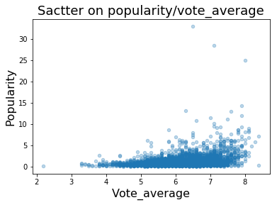

```python
df_small.plot(x = 'vote_average', y = 'popularity', kind = 'scatter', alpha = 0.3)
plt.xlabel('Vote_average',fontsize = 16)
plt.ylabel('Popularity',fontsize = 16)
plt.title('Sactter on popularity/vote_average', fontsize = 18)
```

**从图中可以看出得分与流行程度呈正相关。**

```
Text(0.5,1,'Sactter on revenue/budge')
```

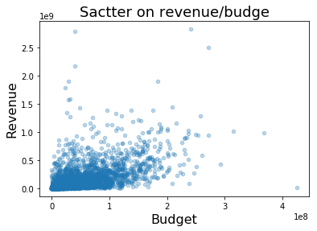

```python
df_small.plot(x= 'budget_adj',y='revenue_adj',kind='scatter', alpha=0.3)
plt.xlabel('Budget',fontsize = 16)
plt.ylabel('Revenue',fontsize = 16)
plt.title('Sactter on revenue/budge', fontsize = 18)
```

### 研究问题 2-电影是否拥有主页（homepage），会影响popularity和vote_average吗？

```python
df_for_homepage = df[['popularity','vote_average','has_homepage']]

df_for_homepage.head()
```

|  | popularity | vote_average | has_homepage |
| --- | --- | --- | --- |
| 0 | 32.985763 | 6.5 | True |
| 1 | 28.419936 | 7.1 | True |
| 2 | 13.112507 | 6.3 | True |
| 3 | 11.173104 | 7.5 | True |
| 4 | 9.335014 | 7.3 | True |

**在查看数据的时候，我发现homepage这一列有很多缺失值，所以我根据是否有主页（‘has_homepage’）进行分组，再研究提出的问题**

```python
df_mean = df_for_homepage.groupby('has_homepage').mean()
df_mean
```

| has_homepage | popularity | vote_average |
| --- | --- | --- |
| False | 0.515638 | 5.906886 |
| True | 0.999706 | 6.158992 |

**再对电影是否拥有主页进行分组后，展示各列平均值。可以明显看出‘has_homepage’为True的时候，流行程度更高；而得分之间的差别不大**

## 结论

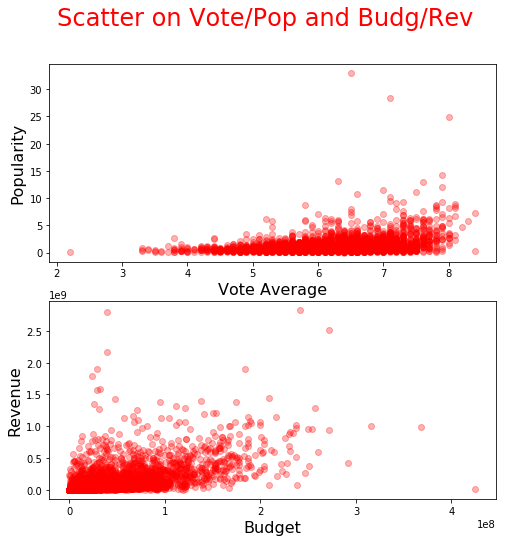

```python
fig = plt.figure(figsize=(8,8))
ax1 = fig.add_subplot(2, 1, 1)
ax2 = fig.add_subplot(2, 1, 2)

x1 = df_small['vote_average']
y1 = df_small['popularity']
x2 = df_small['budget_adj']
y2 = df_small['revenue_adj']

ax1.scatter(x1, y1, color = 'r', alpha = 0.3, label = "All")
ax2.scatter(x2, y2, color = 'r', alpha = 0.3, label = "All")

ax1.set_ylabel('Popularity', fontsize = 16)
ax1.set_xlabel('Vote Average', fontsize = 16)
ax2.set_ylabel('Revenue', fontsize = 16)
ax2.set_xlabel('Budget', fontsize = 16)

fig.suptitle('Scatter on Vote/Pop and Budg/Rev',
             fontsize = 24, color = 'red');
```

**结论2** 对于问题2来说：若电影具有自己的网站主页（homepage），那么其流行程度（popularity）相比没有homepage的电影明显更高；但是，有无homepage对得分（vote_average）的影响不大。

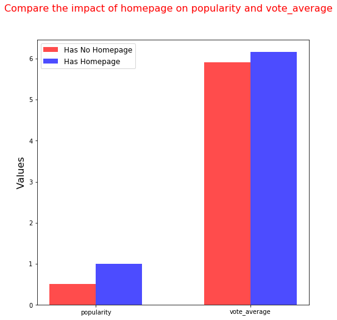

```python
fig = plt.figure(figsize=(8,8))

ax = fig.add_subplot(1,1,1)
ind = np.arange(len(df_mean.iloc[0]))

w = 0.3

ax.bar(ind, df_mean.iloc[0], color = 'r',
       alpha = 0.7, width = w, label = "Has No Homepage")
ax.bar(ind+w, df_mean.iloc[1], color = 'b',
       alpha = 0.7, width = w, label = "Has Homepage")

ax.legend(loc = 'best', fontsize = 12)
ax.set_xticks(ind+w/2)

mean_lable = ['popularity','vote_average']
ax.set_xticklabels(mean_lable)
ax.set_ylabel('Values', fontsize = 16)
fig.suptitle('Compare the impact of homepage on popularity and vote_average',
             fontsize = 16, color = 'red');
```

**分析局限**

1.数据质量。在数据中有大量0投入，0收入的电影，猜测可能是独立电影之类的，这类数据在加到商业电影分析的工作中可能会影响结论。如果后续可以的话，可以考虑将两类电影拆开或者用新的列区分开。可以让结论更加有针对性。

2.分析中重点使用的是财务纬度的收入和预算，可以支撑结论。

```python
# from subprocess import call
# call(['python', '-m', 'nbconvert', 'Investigate_a_Dataset.ipynb'])
```